# Assignment 1

Dylan Culp

9/16/2020

```r
 library(tidycensus)
 library(tidyverse)
```

Here are my selected variables:

```r
vars <- c(tot_hh = "H001001",
         tot_rural_hh = "H002005",
         tot_rent_hh = "H004004",
         avg_hh_size = "H012001",
         tot_pop = "P003001",
         nh_white_pop = "P005003",
         nh_black_pop = "P005004",
         nh_asian_pop = "P005006",
         hispanic_pop = "P005010",
         med_age = "P013001")
```

Now I will load 2010 Decennial data for King County, WA:

```r
 king_tracts <- get_decennial(geography = "tract", variables = vars,
                            state = "WA", county = "King",
                            output = "wide") %>%
     mutate(rural = (tot_rural_hh == tot_hh) ,
            pct_rental = tot_rent_hh / tot_hh,
            majority_race_eth = case_when(
                nh_white_pop / tot_pop > 0.5 ~ "nh_white",
              nh_black_pop / tot_pop > 0.5 ~ "nh_black",
                nh_asian_pop / tot_pop > 0.5 ~ "nh_asian",
                hispanic_pop / tot_pop > 0.5 ~ "hispanic",
                (nh_white_pop + nh_black_pop + nh_asian_pop + hispanic_pop) /
                    tot_pop < 0.5 ~ "other",
                TRUE ~ "None")) %>%
     filter(tot_pop > 0, tot_hh > 0) %>%
     select(GEOID, rural, majority_race_eth,
            pct_rental, avg_hh_size, tot_pop, med_age)
```

1. Simple Scatterplot–bivariate

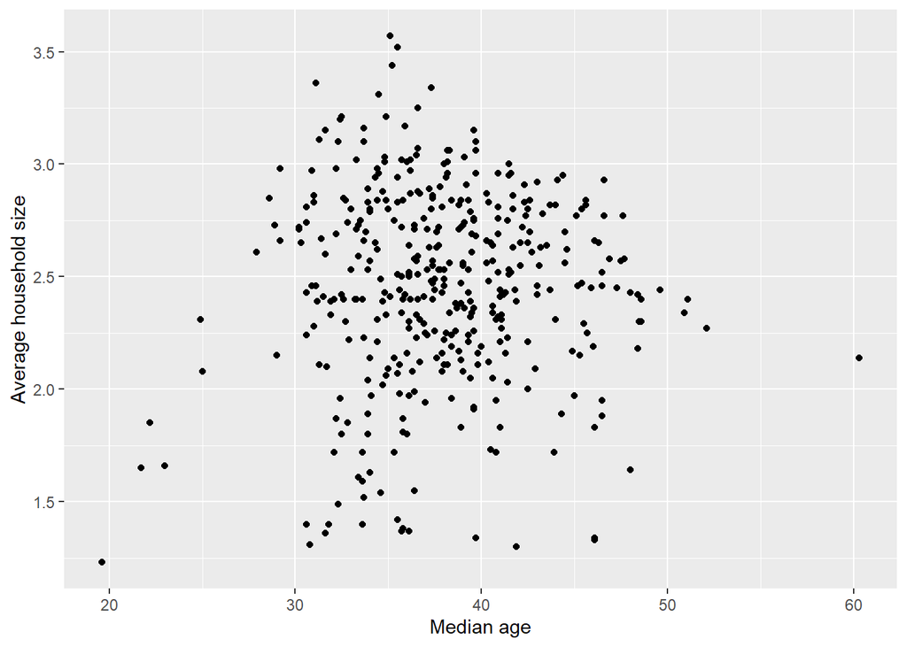

```r
ggplot(king_tracts,
        aes(x = med_age,
            y = avg_hh_size,)) +
     geom_point() +
     scale_x_continuous(name = "Median age",
                        breaks = seq(10, 80, by = 10),
                        labels = paste(seq(10, 80, by = 10))) +
     scale_y_continuous(name = "Average household size",
                      breaks = seq(1, 4, by = 0.5))
```

```r
                         labels = paste(seq(1, 4, by = 0.5))+
     theme_bw()
```

There does not appear to be a meaningful relationship between median age and average household size in King County.

2. Colorful Scatterplot (three variables)

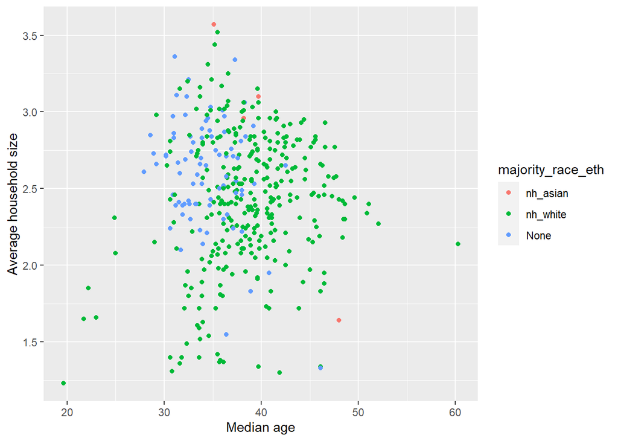

```r
ggplot(king_tracts,
        aes(x = med_age,
            y = avg_hh_size,
            color = majority_race_eth)) +
     geom_point() +
     scale_x_continuous(name = "Median age",
                        breaks = seq(10, 80, by = 10),
                        labels = paste(seq(10, 80, by = 10))) +
     scale_y_continuous(name = "Average household size",
                      breaks = seq(1, 4, by = 0.5))
```

```r
                         labels = paste(seq(1, 4, by = 0.5))+
       scale_color_discrete(name = "Majority race/ethnicity",
                       labels = c("Hispanic",
                                  "Non-Hispanic Asian",
                                  "Non-Hispanic white",
                                  "No majority")) +
                           theme_bw()
```

This plot uses the same x and y axes, with race/ethnicity illustrated by color. While little to no correlation between median age and household size remains, adding race/ethnicity shows a general relationship. Interestingly, the most diverse tracts (those without a majority race) tend to be on the younger side, with medians between 30 and 45. These households also tend to have a higher size.

3. Simple Histogram

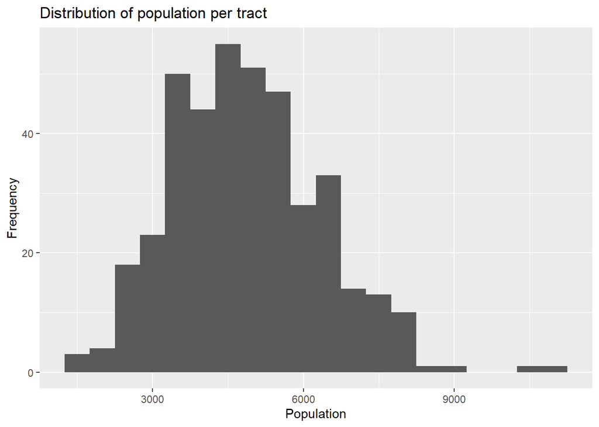

```r
 qplot(king_tracts$tot_pop,
       main = "Distribution of population per tract",
       xlab="Population",
       ylab="Frequency",
       binwidth = 500)
```

This is a simple histogram showing the amount of people in each census tract. I had expected there to be more consistency between the population of each tract.

4. Barplot

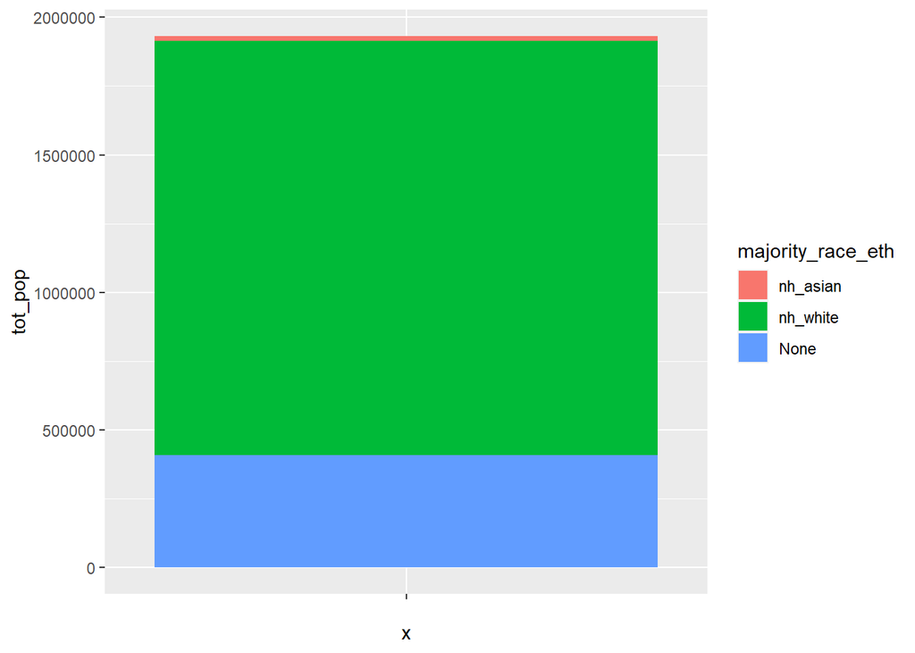

```r
ggplot(king_tracts, aes(x="", y=tot_pop, fill= majority_race_eth))+
  geom_bar(width=1, stat = "identity")
```

This bar plot breaks down the tracts by majority racial/ethnic status.

5. Pie Chart

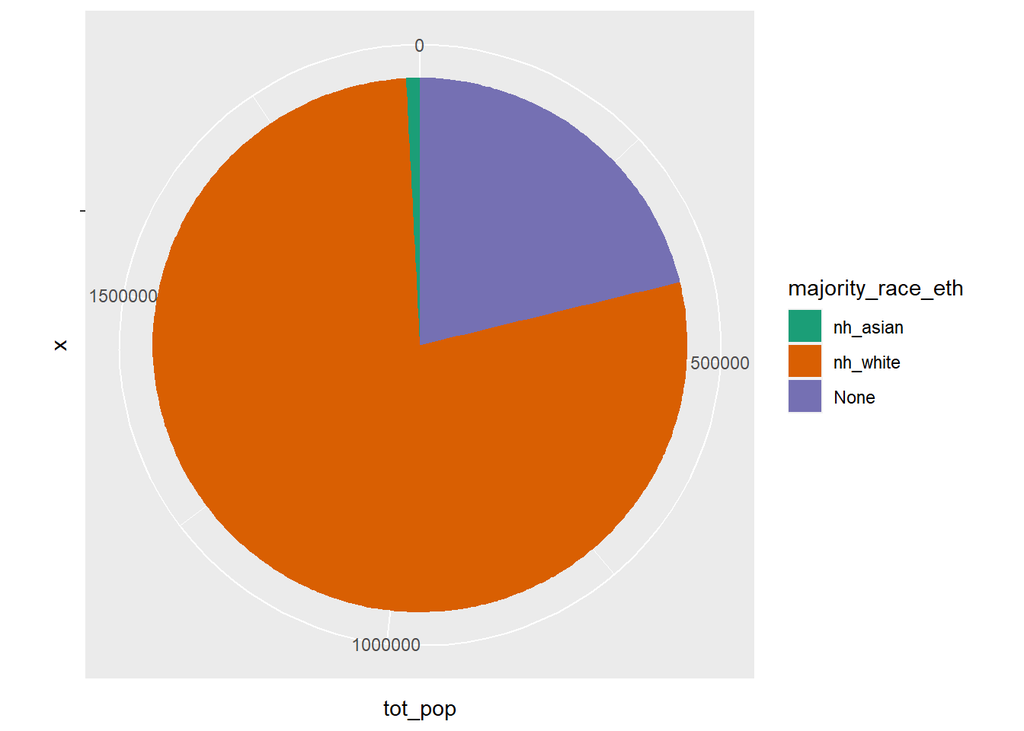

```r
ggplot(king_tracts, aes(x="", y=tot_pop, fill= majority_race_eth))+
  geom_bar(width=1, stat = "identity")+
  coord_polar("y", start=0)+
  scale_fill_brewer(palette="Dark2")
```

This is the same data in pie chart form, with a fresh color scheme to boot.

6. Box Plot

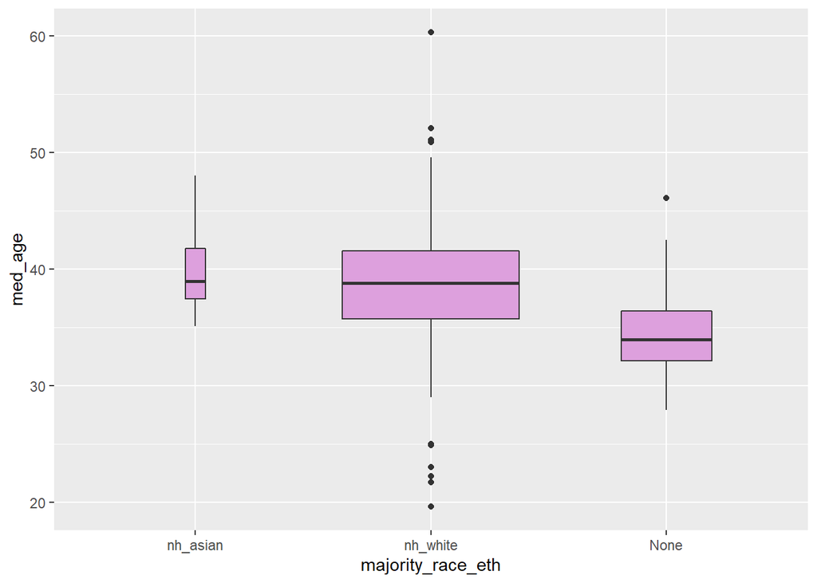

```r
ggplot(king_tracts, aes(majority_race_eth, med_age ))+
  geom_boxplot(varwidth=T, fill="plum")
```

7. Violin Plot

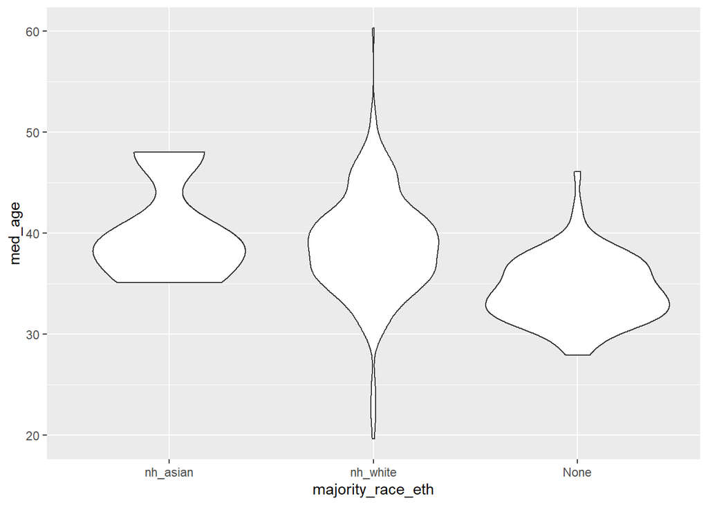

```r
ggplot(king_tracts, aes(majority_race_eth, med_age))+
  geom_violin()
```

This is the same data as the box plot, but shown with Violins.I think I find this one easier to understand at a glance.

8. Line Chart

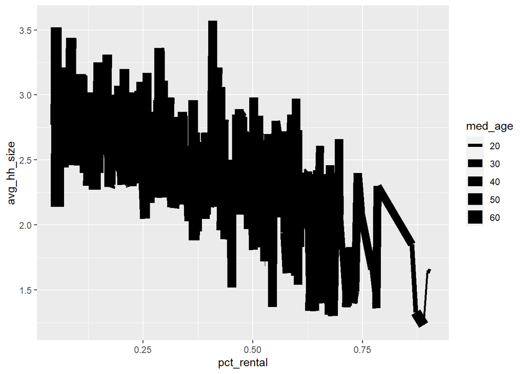

```r
ggplot(king_tracts, aes(x=pct_rental, y=avg_hh_size, size=med_age))+geom_line()
```

I’ve plotted three variables on this line chart, illustrated through the line thickness, x axis, and y axis. It looks a bit ugly, and I’m not sure this is the correct use of a line graph, but I’m happy to have the option.

9. A simple bar chart

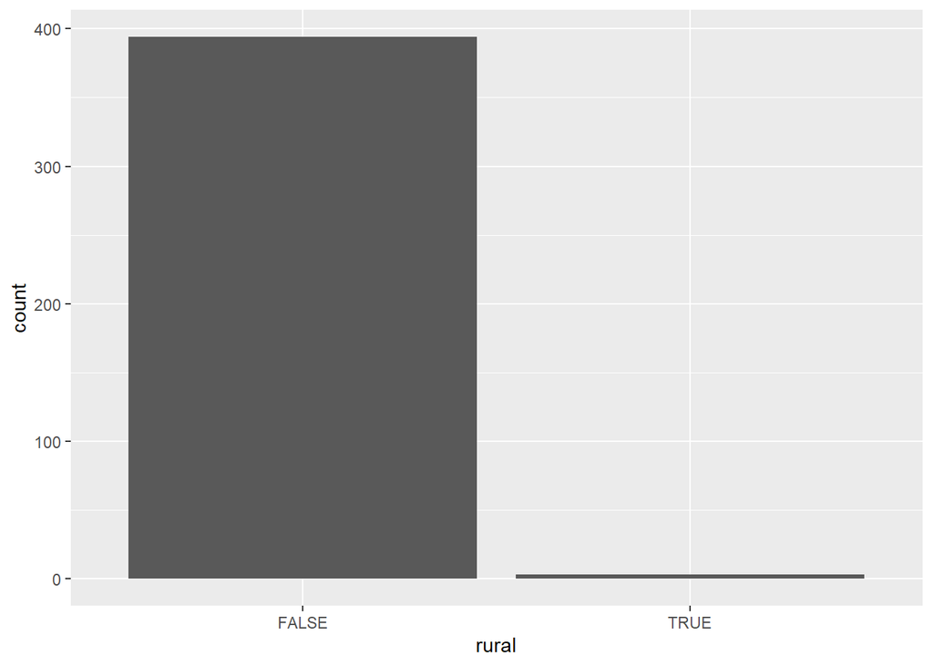

```r
ggplot(king_tracts, aes (x=rural))+ geom_bar()
```

My dataset only has 4 rural tracts out of 397 observations. I haven’t used the rural category until this point.

10. Density Plot

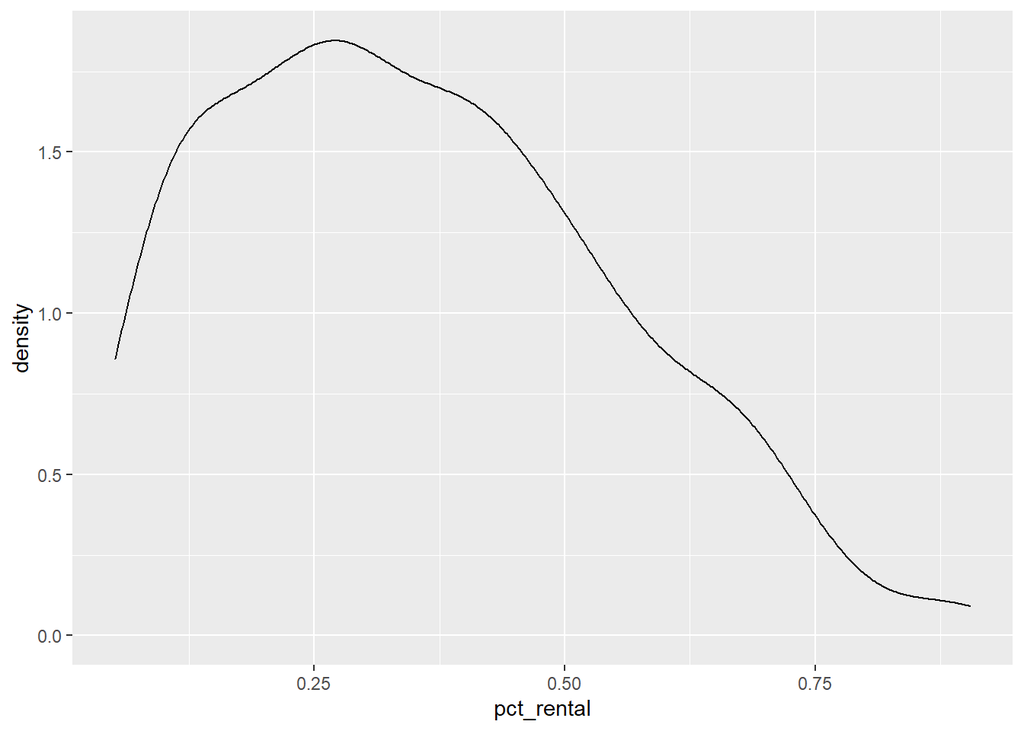

```r
ggplot(king_tracts, aes(pct_rental))+
         geom_density()
```